# Homework Solution

The solutions below will use base R syntax as learned in modules 1-3.

First let’s load our libraries

```r
library(ggplot2)
library(openxlsx)
library(reshape2)
library(scales)
```

## Multiple Choice

Given the following graph…

```r
title <- 'Fuel Economy of Popular Cars'
legend.title <- 'Type of Car'

p <- ggplot(mpg, aes(displ, hwy, color = class)) +
  geom_point()
```

The dataset `mpg` is actually a dataset built into R. When we download R or install packages, each comes with datasets. Similar to functions, you can type `?mpg` in the console to find its metadata. Built in datasets such as `mpg` allow us to create reproducible examples–code that anyone can run on their computer as long as they have R and that particular package.

To see all the built-in datasets available, type `data()` into your console. Call some additional libraries and run `data()` again.

### Which are ways that you can change the legend titles? Select all that apply.

a. `scale_color_discrete(name = legend.title)`

2. `theme(legend.title = element_text(legend.title))`
3. `theme(legend.text = element_text(title = legend.title))`

d. `labs(color = legend.title)`

We can change the legend titles with **a** and **d**. `theme()` can change the appearance (e.g. font, text size, text face, position) of an existing legend title but we can’t create or rename it with the `theme()` layer.

### Which are ways that you can add a title to your graph? Select all that apply.

a. `labs(title = title)`

b. `ggtitle(title)`

c. `annotate('text', label = title, x = min(mpg$displ) + 3.5, y = max(mpg$hwy), size = 4)`

4. `theme(plot.title = element_text(title))`

Options **a**, **b**, and **c** are valid options. Again, `theme()` can help change the appearance of an existing title but can’t generate one.

### So what’s the difference between `labs()`, `ggtitle()`, and `annotate()`?

`ggtitle()` is the equivalent of using `labs(title = 'My title', subtitle = 'My subtitle')`.

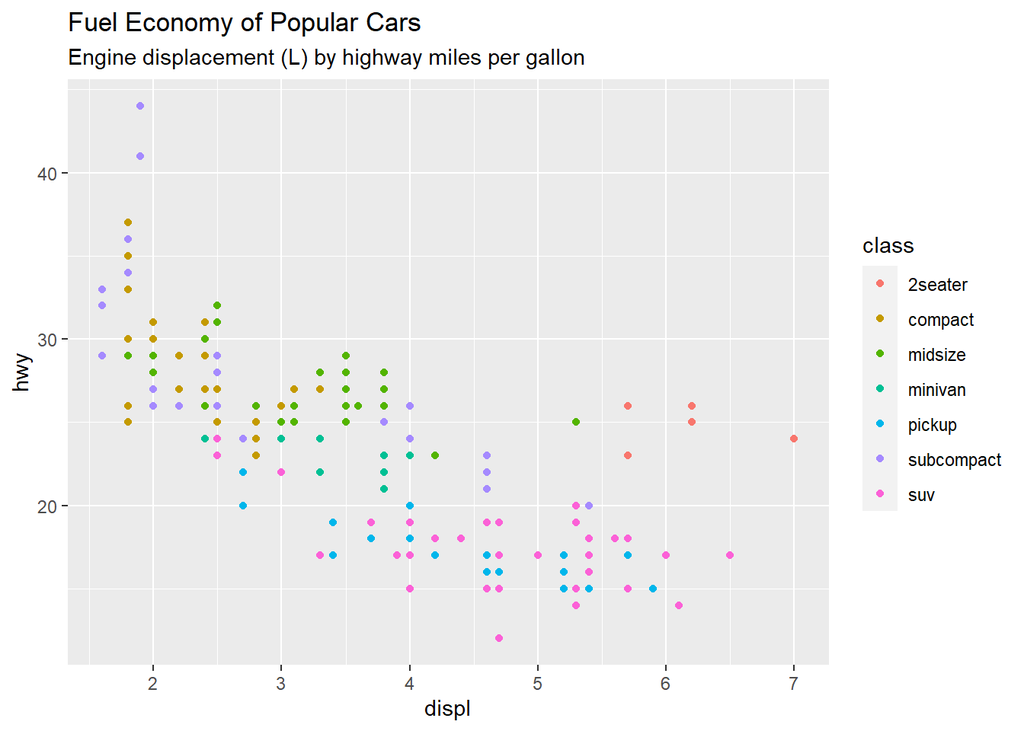

```r
p + ggtitle(title, 'Engine displacement (L) by highway miles per gallon')
```

With `ggtitle()` and `labs()` you can adjust its vertical position with `theme()` but they will still reserve blank space above the plotting region for the title.

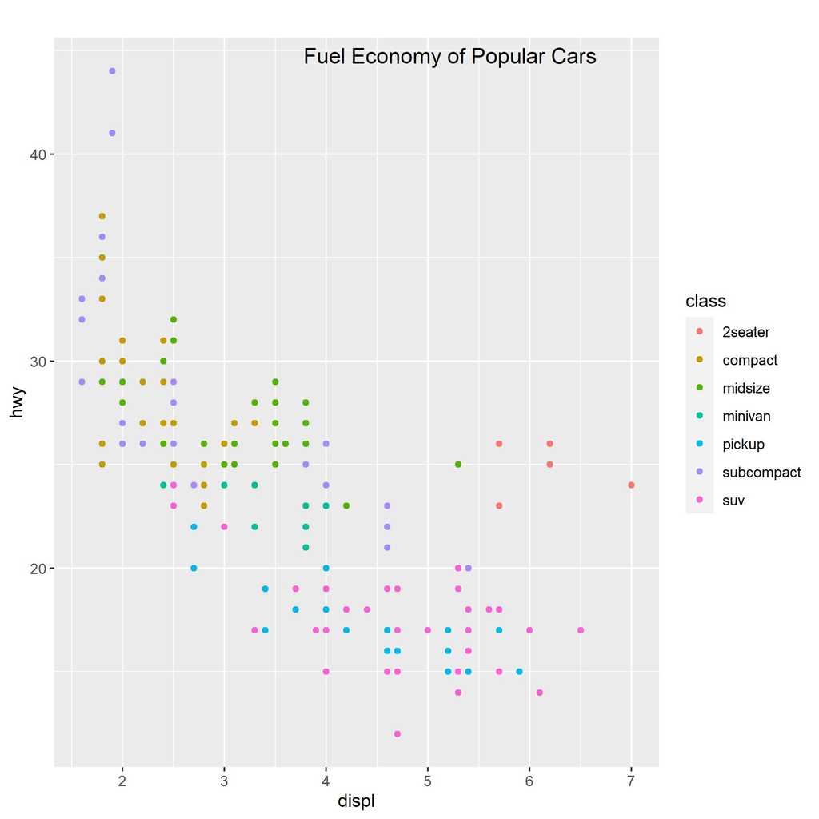

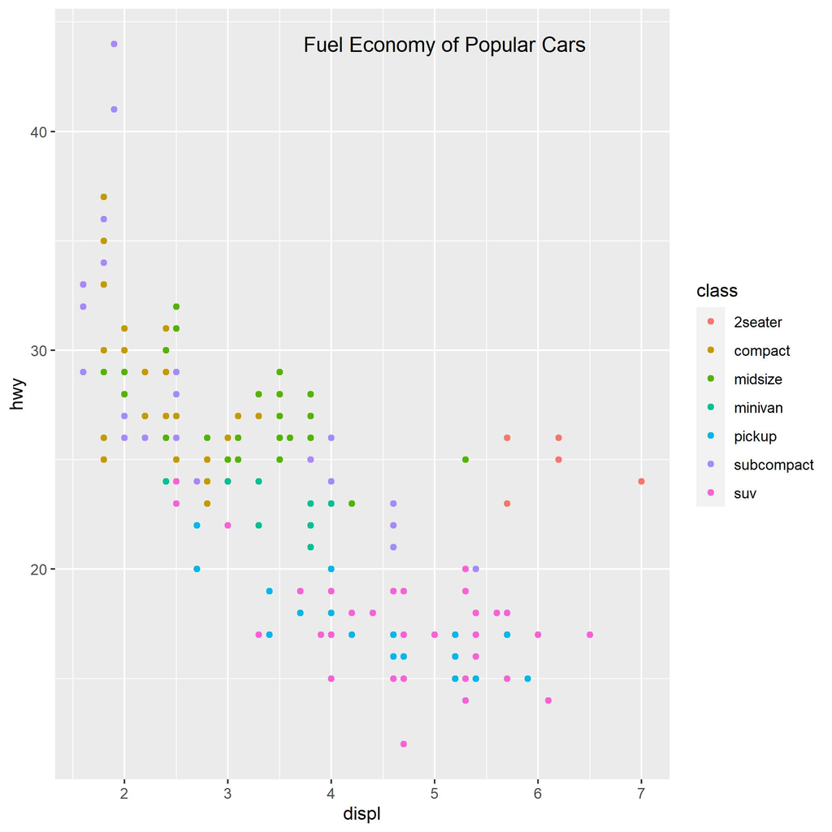

```r
# Moving your title inside with ggtitle() or labs()
p +
  ggtitle(title) +
  theme(plot.title = element_text(vjust = -8, hjust = .8))

# Moving your title inside with annotation
p +
  annotate('text', label = title, x = min(mpg$displ) + 3.5, y = max(mpg$hwy), size = 4.5)
```

## Cereal Data

### Create a scatterplot exploring select breakfast cereals. What is the relationship between cereal ratings and grams of sugar?

It appears that cereals with more sugar receive a lower rating. Perhaps a particular demographic was rating these cereals or maybe these ratings were derived from consumer reports…

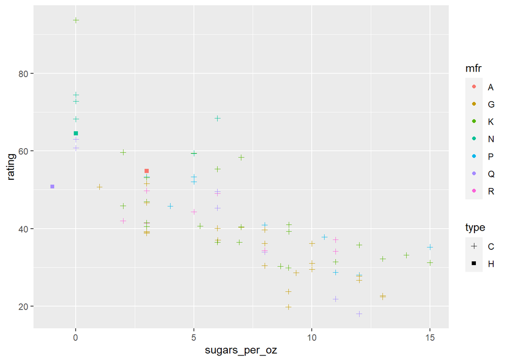

```r
# read in excel sheet
my.dir <- 'C:/Users/clam/Documents/github/intro-ggplot2/data'
df <- read.xlsx(file.path(my.dir, 'cereal.xlsx'))

# calculate sugars per oz in new column
df$sugars_per_oz <- df$sugars/df$weight

# plot it
ggplot(df,
       aes(x = sugars_per_oz,
           y = rating,
           color = mfr,
           shape = type)) +
  geom_point() +
  scale_shape_manual(values = c(3, 15))
```

### Notice anything interesting with the sugar column in the dataset?

Using graphs to explore this dataset, it looks like negative values exist! The range of values for the `sugars_per_oz` column is -1 and 15.

```r
range(df$sugars_per_oz)
```

```
## [1] -1 15
```

Quaker Oatmeal has -1 sugars/oz?!

```r
df[df$sugars_per_oz == -1, ]
```

```
##              name mfr type calories protein fat sodium fiber carbo sugars
## 58 Quaker Oatmeal   Q    H      100       5   2      0   2.7    -1     -1
##    potass vitamins shelf weight cups   rating sugars_per_oz
## 58    110        0     1      1 0.67 50.82839            -1
```

Golden Crisp and Smacks have the most sugars/oz.

```r
df[df$sugars_per_oz == 15, ]
```

```
##            name mfr type calories protein fat sodium fiber carbo sugars potass
## 31 Golden Crisp   P    C      100       2   0     45     0    11     15     40
## 67       Smacks   K    C      110       2   1     70     1     9     15     40
##    vitamins shelf weight cups   rating sugars_per_oz
## 31       25     1      1 0.88 35.25244            15
## 67       25     2      1 0.75 31.23005            15
```

Cereals with the words ‘Wheat’ or ‘Rice’ or ‘Fiber’ have no sugars

```r
df[df$sugars_per_oz == 0, ]
```

```
##                         name mfr type calories protein fat sodium fiber carbo
## 4  All-Bran with Extra Fiber   K    C       50       4   0    140    14     8
## 21    Cream of Wheat (Quick)   N    H      100       3   0     80     1    21
## 55               Puffed Rice   Q    C       50       1   0      0     0    13
## 56              Puffed Wheat   Q    C       50       2   0      0     1    10
## 64            Shredded Wheat   N    C       80       2   0      0     3    16
## 65    Shredded Wheat 'n'Bran   N    C       90       3   0      0     4    19
## 66 Shredded Wheat spoon size   N    C       90       3   0      0     3    20
##    sugars potass vitamins shelf weight cups   rating sugars_per_oz
## 4       0    330       25     3   1.00 0.50 93.70491             0
## 21      0     -1        0     2   1.00 1.00 64.53382             0
## 55      0     15        0     3   0.50 1.00 60.75611             0
## 56      0     50        0     3   0.50 1.00 63.00565             0
## 64      0     95        0     1   0.83 1.00 68.23588             0
## 65      0    140        0     1   1.00 0.67 74.47295             0
## 66      0    120        0     1   1.00 0.67 72.80179             0
```

### On which shelf can you find the cereal with the highest rating?

We can find the highest rated cereal (All-Bran with Extra Fiber) on the third shelf.

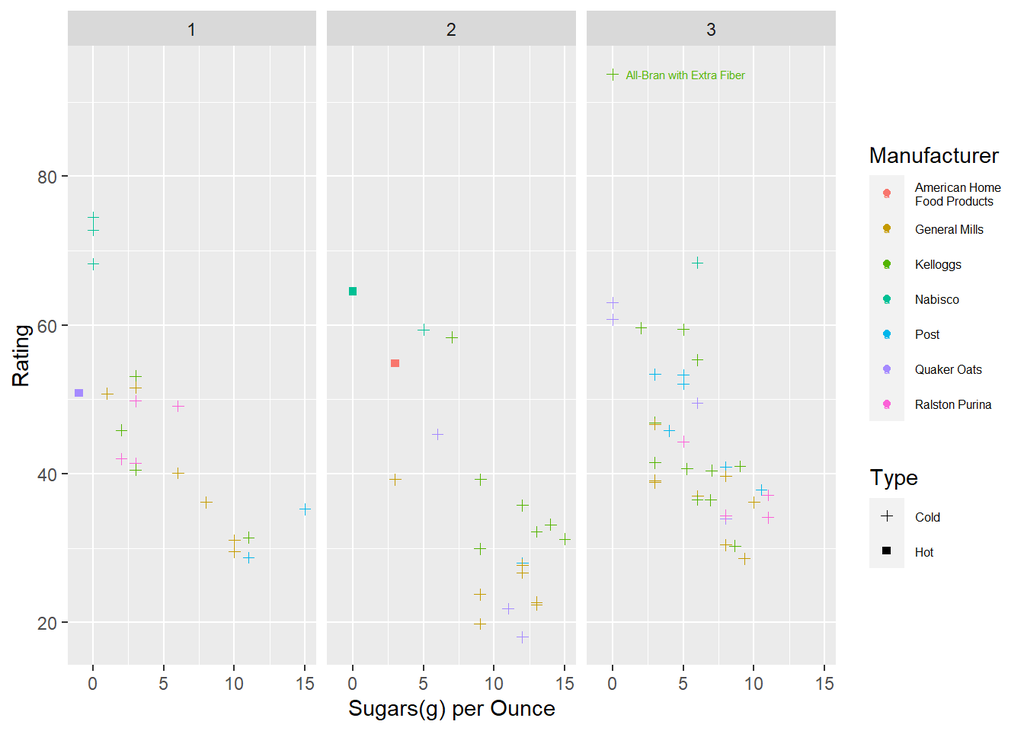

```r
# create a new data frame with the highest rated cereal
df2 <- df[df$rating == max(df$rating), ]

ggplot(df,
       aes(x = sugars_per_oz,
           y = rating,
           color = mfr,
           shape = type)) +
  geom_point() +
  scale_shape_manual(values = c(3, 15),
                     labels = c("Cold", "Hot")) +
  facet_wrap(vars(shelf)) +
  labs(x = 'Sugars(g) per Ounce',
       y = 'Rating',
       color = 'Manufacturer',
       shape = 'Type') +
  scale_color_discrete(labels = c("American Home\nFood Products",
                                  "General Mills",
                                  "Kelloggs",
                                  "Nabisco",
                                  "Post",
                                  "Quaker Oats",
                                  "Ralston Purina")) +
  geom_text(data = df2,
            aes(x = sugars_per_oz + 1,
                y = rating,
                label = name),
            size = 2,
            hjust = 0) +
  theme(legend.text = element_text(size = 6))
```

## OFM Data

### Create a bar graph of cities & towns with the greatest nominal growth between 2010 and 2020 like the one below…

```r
# read excel sheet
my.dir <- 'C:/Users/clam/Documents/github/intro-ggplot2/data'
df <- read.xlsx(file.path(my.dir, "ofm_april1_population_final_tidied.xlsx"), detectDates = T)

# subset the data for only cities & towns for years 2010 and 2020
df1 <- df[df$Filter == 4 & df$Year_chr %in% c(2010, 2020), ]

# cast the data so that each observation has a 2010 and 2020 estimate
df2 <- dcast(df1, County + Jurisdiction ~ paste0("Year_", Year_chr), value.var = "Estimate")

# calculate the difference
df2$diff <- df2$Year_2020 - df2$Year_2010

# sort the data based on the difference column in decending order
# and take only the top 10 observations
df3 <- head(df2[order(-df2$diff),], 10)

df3
```

```
##    County   Jurisdiction Year_2010 Year_2020   diff
## 33   King        Seattle    608660    761100 152440
## 19   King       Kirkland     48787     90660  41873
## 18   King           Kent     92411    130500  38089
## 4    King       Bellevue    122363    148100  25737
## 31   King      Sammamish     45780     65100  19320
## 7    King         Burien     33313     52300  18987
## 29   King        Redmond     54144     69900  15756
## 65 Pierce         Tacoma    198397    213300  14903
## 30   King         Renton     90927    105500  14573
## 6    King Bothell (part)     17090     29730  12640
```

At this point if we graphed our data, the cities and towns would be in alphabetical order

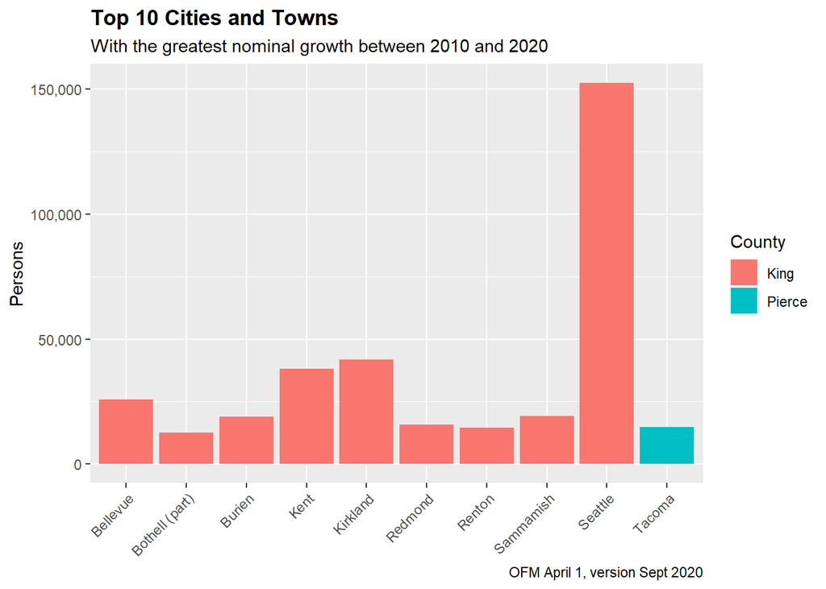

```r
# create our graph and the x-axis is arranged in alphabetical order
ggplot() +
  geom_col(data = df3, aes(x = Jurisdiction, y = diff, fill = County)) +
  scale_y_continuous(labels = label_comma()) +
  theme(axis.text.x = element_text(angle = 45,
                                   hjust = 1,
                                   vjust = 1),
        plot.title = element_text(size = 13, face = 'bold')) +
  labs(title = 'Top 10 Cities and Towns',
       subtitle = 'With the greatest nominal growth between 2010 and 2020',
       caption = 'OFM April 1, version Sept 2020',
       x = NULL,
       y = 'Persons')
```

### Factor and reordering

Using `as.factor()` to convert `Jurisdiction` into a factor datatype and then `reorder()` to reorder based on another column allows the sorting to be based on values of the difference column.

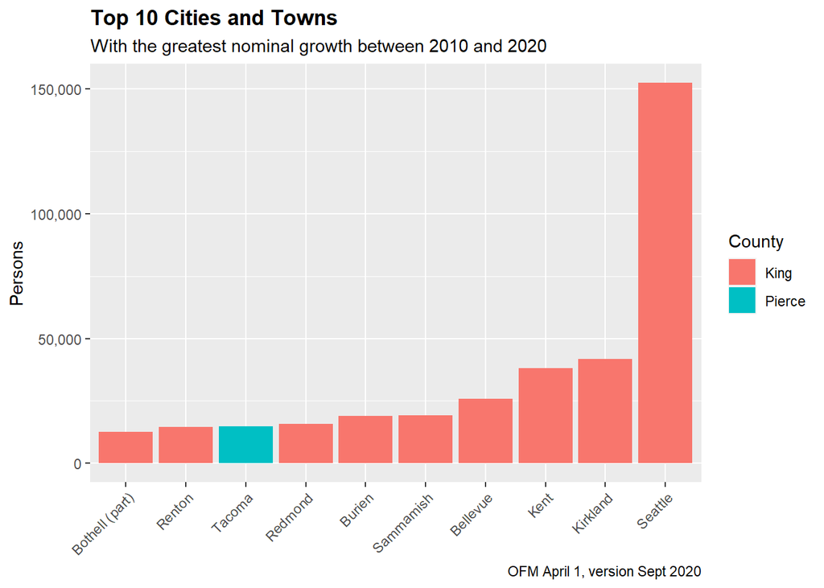

```r
# convert Jurisdiction column into a factor and reorder it based on the difference column
df3$Jurisdiction <- as.factor(df3$Jurisdiction)
df3$Jurisdiction <- reorder(df3$Jurisdiction, df3$diff)

# print the plot again
ggplot() +
  geom_col(data = df3, aes(x = Jurisdiction, y = diff, fill = County)) +
  scale_y_continuous(labels = label_comma()) +
  theme(axis.text.x = element_text(angle = 45,
                                   hjust = 1,
                                   vjust = 1),
        plot.title = element_text(size = 13, face = 'bold')) +
  labs(title = 'Top 10 Cities and Towns',
       subtitle = 'With the greatest nominal growth between 2010 and 2020',
       caption = 'OFM April 1, version Sept 2020',
       x = NULL,
       y = 'Persons')
```